# Signal Detection Theory

## Signal Detection Experiment

### Example

- Signal: + … TRUMP … *****
- Noise: + … … *****

| Stimulus | Present response | Absent Response | Total |
| --- | --- | --- | --- |
| Signal | 75 | 25 | 100 |
| Noise | 30 | 20 | 50 |
| Total | 105 | 45 |  |

## Signal Detection Theory vs. Signal Detection Experiment

- Signal Detection Theory (SDT): Model-based method of assessing performance
- Originally: Developed for signal detection experiments
- Now: Used for perception, memory, decision theory, attitude research, …
- Originally: Two-choice task
- Now: Any form of forced-choice task including rating scales, continuous measures, …

## Signal Detection Theory

Models are a bit more complicated and rely on some knowledge of continuous random variables.

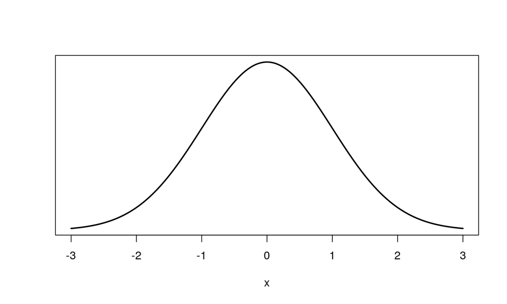

## Probability Theory 101

## Density function

The density function (pdf) of a continuous random variable \(X\) is a function such that the area under the function between \(a\) and \(b\) corresponds to the probability \(Pr(a < x \leq b)\). The value of \(f(x)\) is the probability density.

## Density function

The density function (pdf) of a continuous random variable \(X\) is a function such that the area under the function between \(a\) and \(b\) corresponds to the probability \(Pr(a < x \leq b)\). The value of \(f(x)\) is the probability density.

**Example**

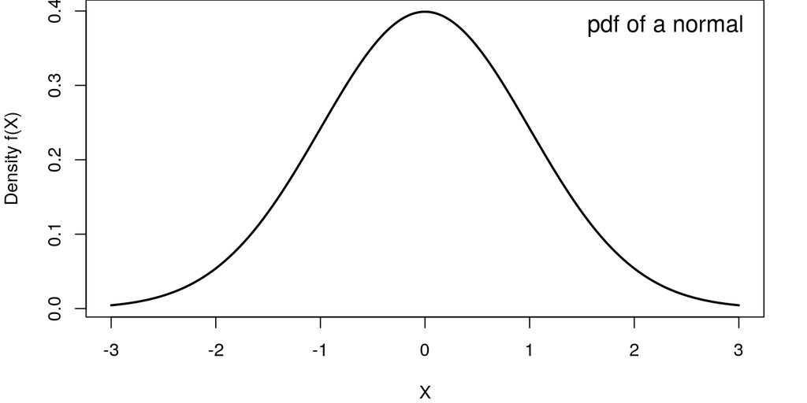

## Density function

The density function (pdf) of a continuous random variable \(X\) is a function such that the area under the function between \(a\) and \(b\) corresponds to the probability \(Pr(a < x \leq b)\). The value of \(f(x)\) is the probability density.

**Example**

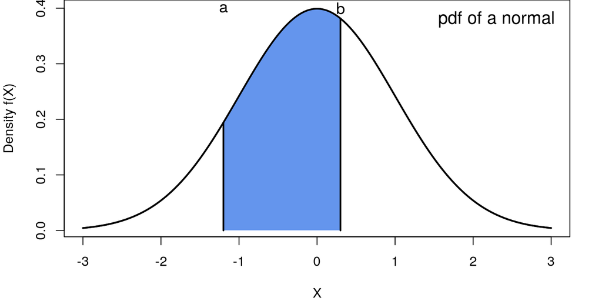

## Density function in R

```r
dnorm(0, mean = 0, sd = 1)
```

```
## [1] 0.3989423
```

## Density function in R

```r
x <- seq(-3, 3, .01)
head(x)
```

```
## [1] -3.00 -2.99 -2.98 -2.97 -2.96 -2.95
```

```r
y <- dnorm(x = x, mean = 0, sd = 1)
head(y)
```

```
## [1] 0.004431848 0.004566590 0.004704958 0.004847033 0.004992899 0.005142641
```

## Density function in R

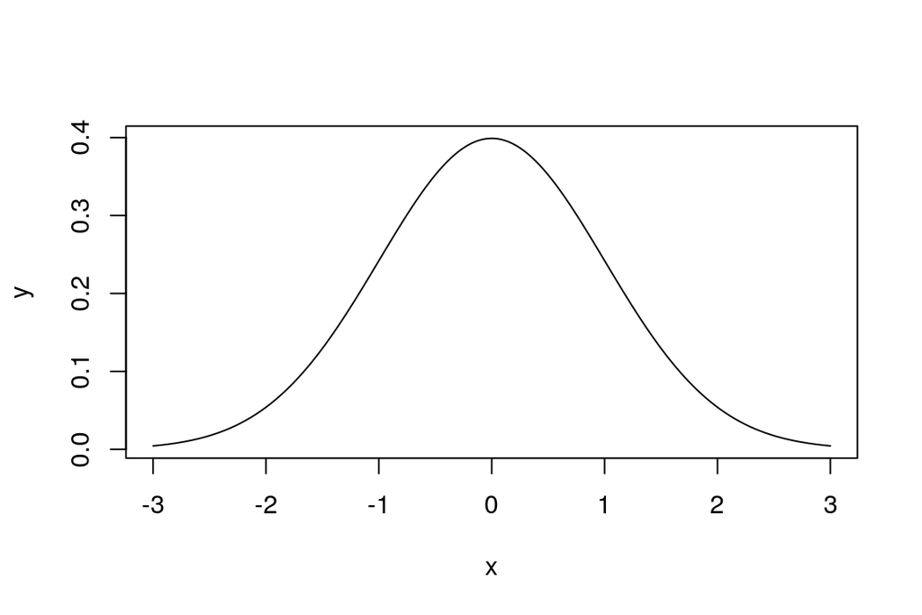

```r
x <- seq(-3, 3, .01)
y <- dnorm(x = x, mean = 0, sd = 1)

plot(x, y, type = "l")
```

## Cumulative Distribution Function

Let \(F\) denote the cumulative distribution function (CDF) of random variable \(X\). Then, \[F(x) = Pr(X \leq x)\].

## Cumulative Distribution Function

Let \(F\) denote the cumulative distribution function (CDF) of random variable \(X\). \[F(x) = Pr(X \leq x)\].

**Example**

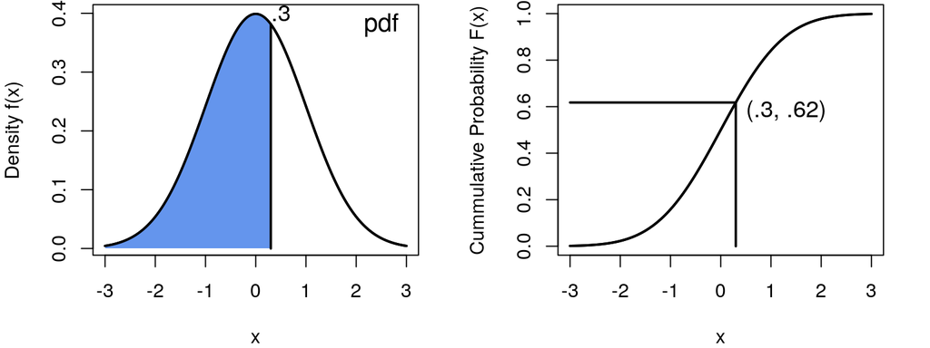

## Using CDF and pdf

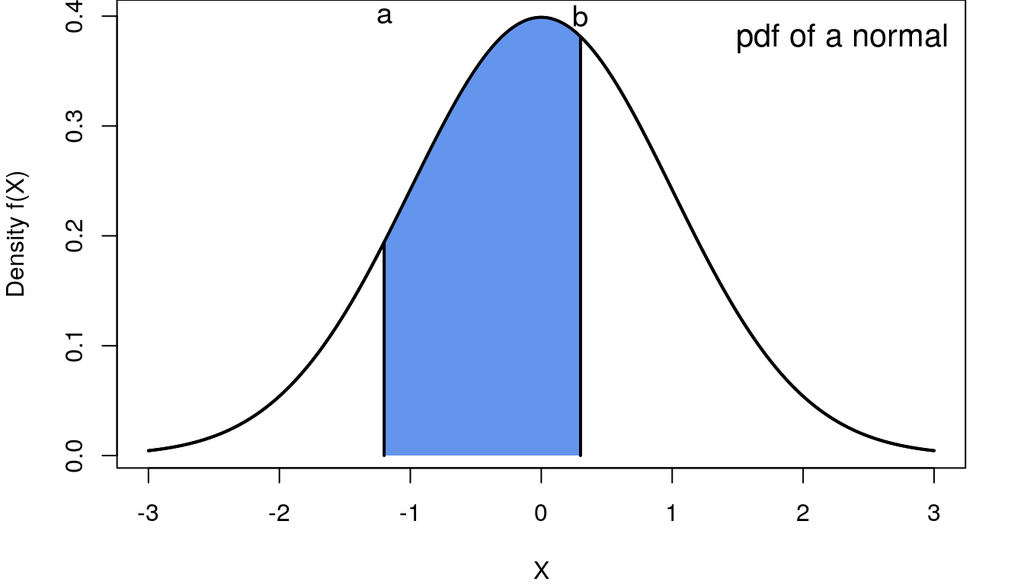

**What is \(Pr(a < x \leq b)\)**

## Using CDF and pdf

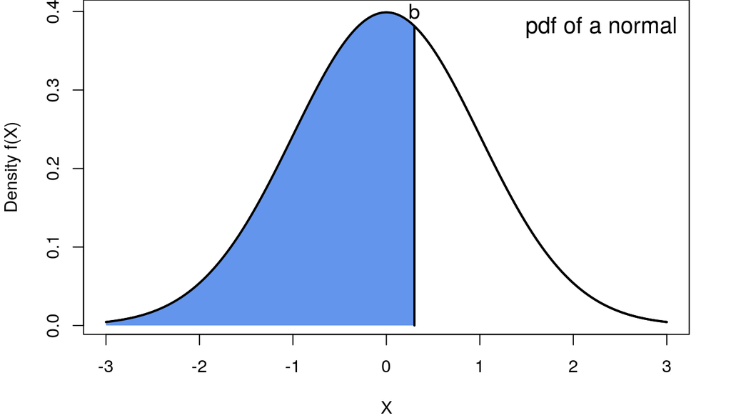

## Using CDF and pdf

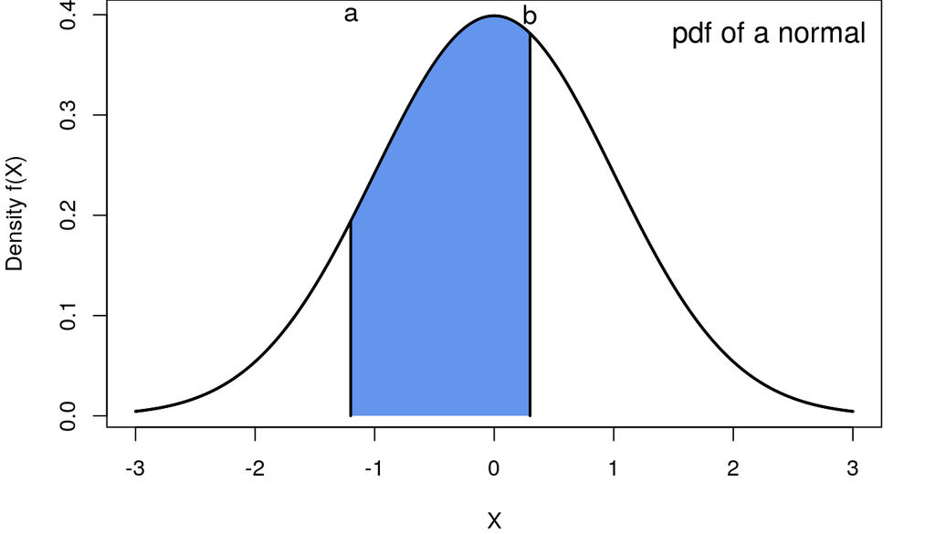

**What is \(Pr(a < x \leq b)\)**

## Using CDF and pdf

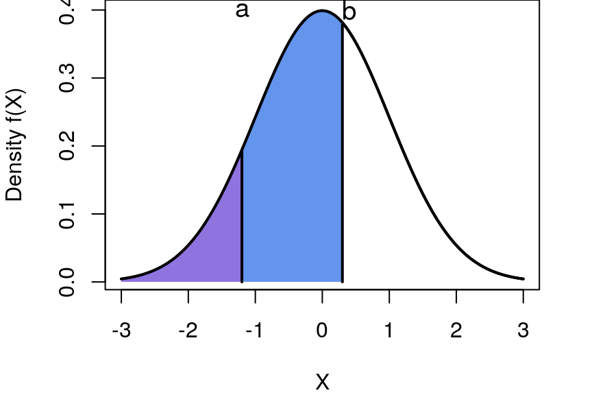

\[Pr(a < x \leq b) = F(b) - F(a)\]

## Using CDF and pdf

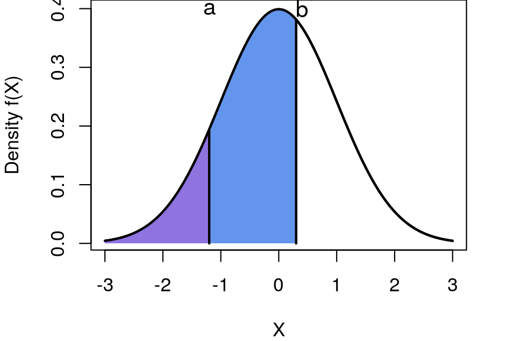

\[Pr(a < x \leq b) = F(b) - F(a)\]

```r
pnorm(.3, 0, 1) - pnorm(-1.2, 0, 1)
```

```
## [1] 0.5028418
```

## Quantile Function

The \(p^{th}\) quantile of a distribution is the value \(q_p\) such that \(Pr(X \leq q_p) = p\).

- Reverse of the CDF

## Quantile Function

The \(p^{th}\) quantile of a distribution is the value \(q_p\) such that \(Pr(X \leq q_p) = p\).

**Reverse of the CDF**

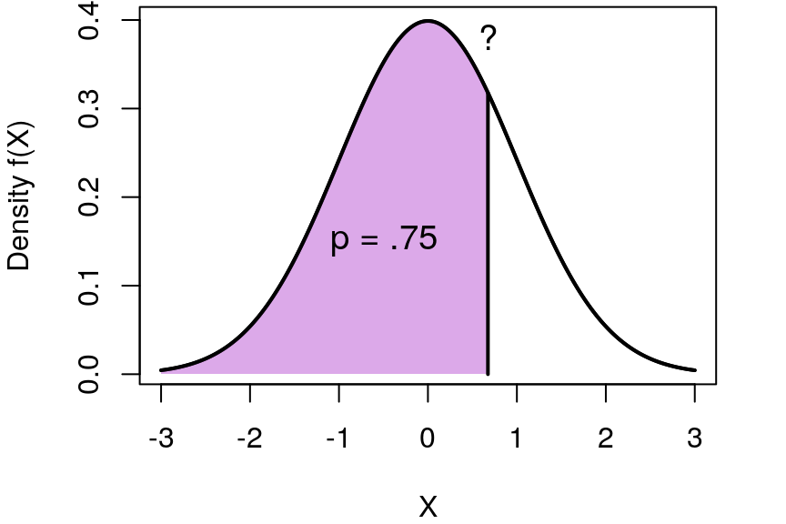

## Quantile Function

The \(p^{th}\) quantile of a distribution is the value \(q_p\) such that \(Pr(X \leq q_p) = p\).

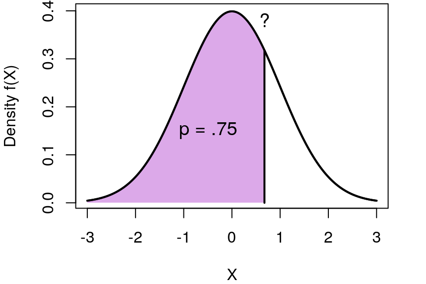

```r
qnorm(.75, mean = 0, sd = 1)
```

```
## [1] 0.6744898
```

## Sampling from a Continuous Random Variable

For example \(Y \sim \mbox{Normal}(0, 1)\)

## Sampling from a Continuous Random Variable

For example \(Y \sim \mbox{Normal}(0, 1)\)

```r
rnorm(5, mean = 0, sd = 1)
```

```
## [1] -1.11818020 -0.52691477 -0.07321602  1.81819647 -0.81147264
```

## Trial & Error

- Plot the density function of a \(\mbox{Normal}(-10, 10)\). What is a reasonable "zoom" for the plot and how do you achieve it?
- Draw a histogram (`hist()`) with 10000 realizations from a \(\mbox{Normal}(-10, 10)\). How does it compare to the density function plot?
- Find the median of a standard normal distribution \(\mbox{Normal}(0, 1)\) using `dnorm()`, `pnorm()`, or `qnorm()`

## Signal Detection Theory Model

## SDT model for subliminal perception

General idea: Perception strength varies gradually, but is on average higher when the stimulus is present compared to absent.

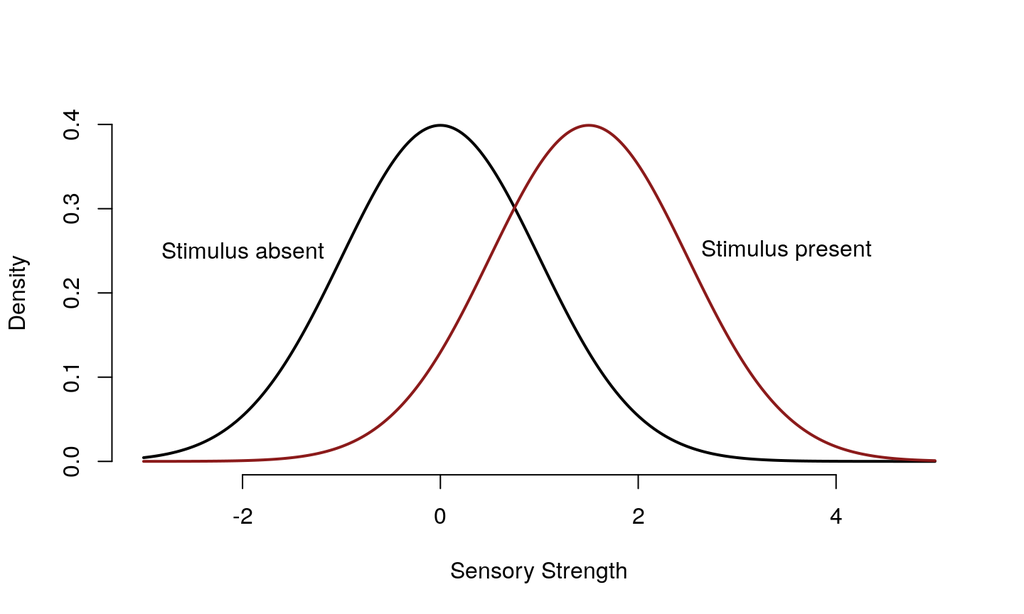

## SDT model for subliminal perception

General idea: Perception strength varies gradually, but is on average higher when the stimulus is present compared to absent.

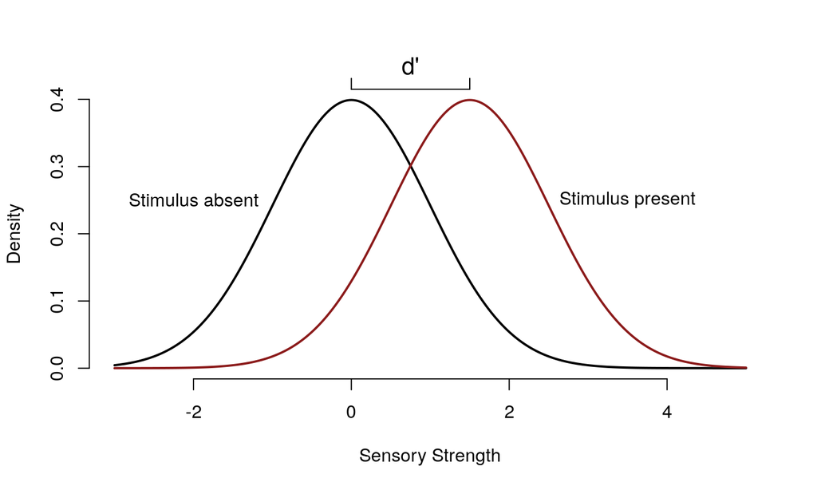

## SDT model for subliminal perception

A criterion determines the response made.

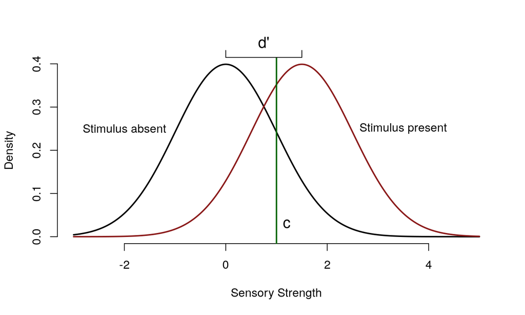

## SDT model compared to HT model

One parameter for perception ability, one for response bias

- \(d'\) corresponds to \(d\)
- \(c\) corresponds to \(g\)

## SDT model predictions for H, M, F, C

What corresponds to the probability of hit? Area under the curve!

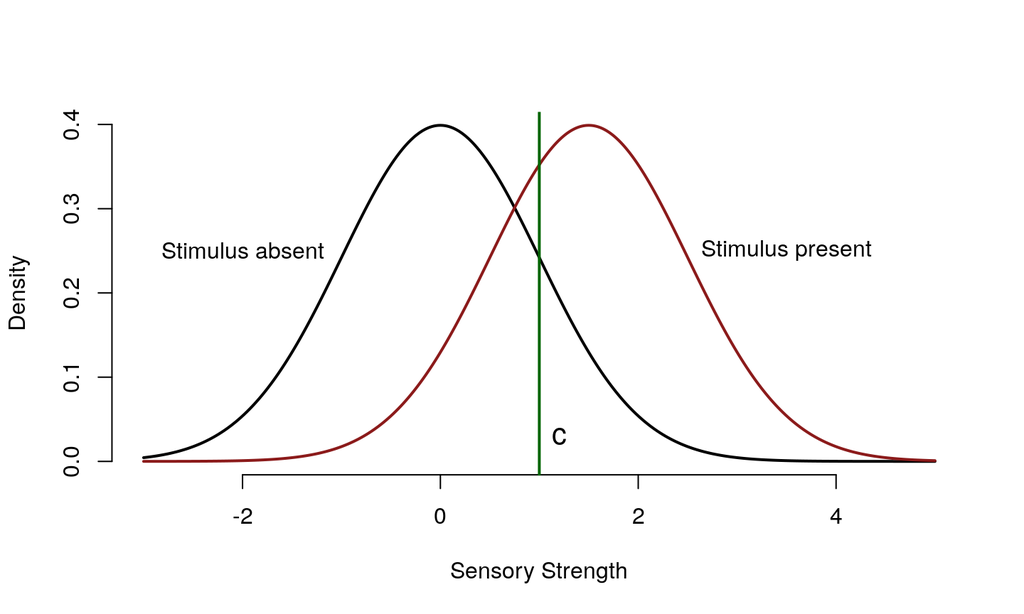

## SDT model predictions for H, M, F, C

What corresponds to the probability of hit? Area under the curve!

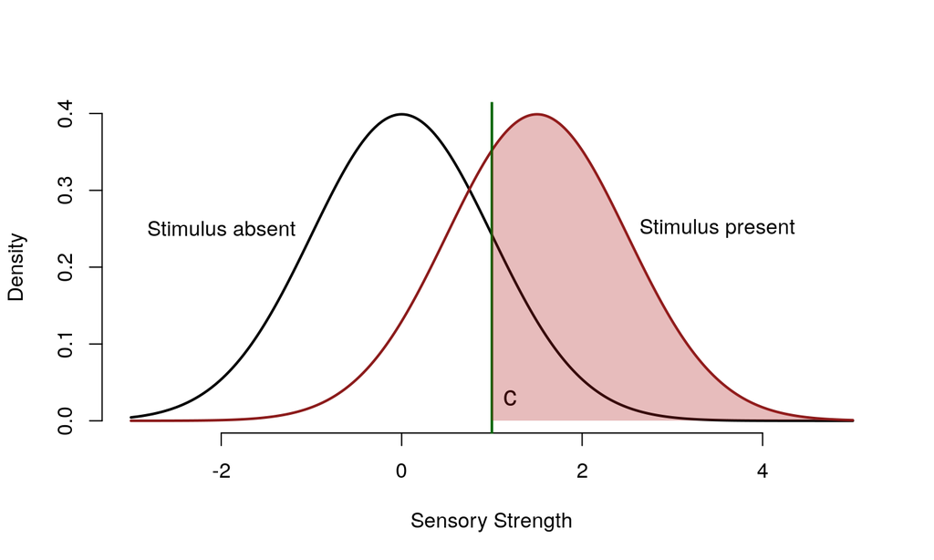

## SDT model predictions for H, M, F, C

What corresponds to the probability of miss?

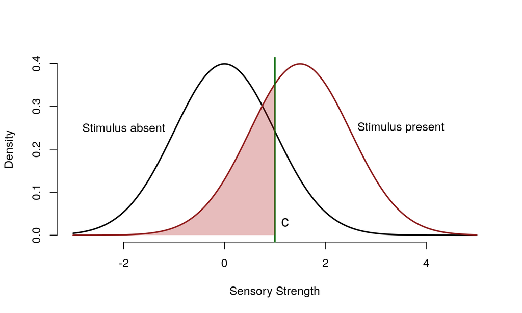

## SDT model predictions for H, M, F, C

What corresponds to the probability of false alarm?

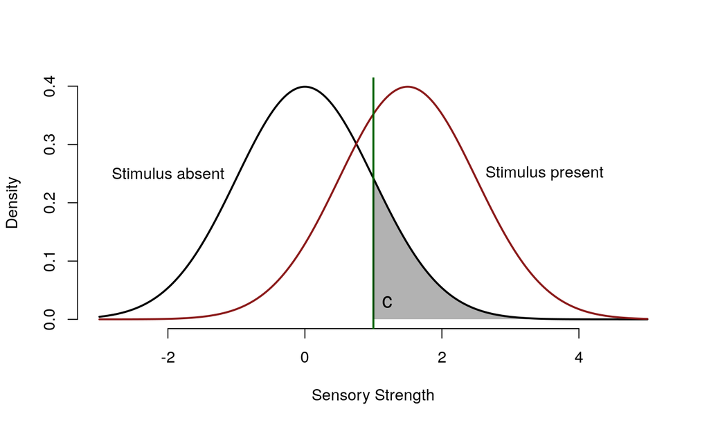

## SDT model predictions for H, M, F, C

What corresponds to the probability of correct rejection?

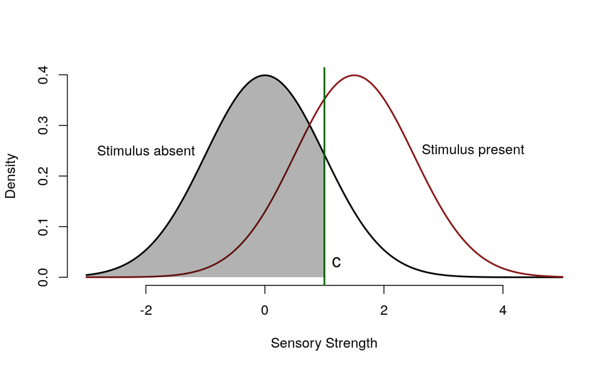

## SDT model predictions for H, M, F, C

Let the CDF of a standard normal be \(\Phi(x)\). Then

\[Pr(\mbox{correct rejection}) = \Phi(c)\]

\[Pr(\mbox{false alarm}) = 1 - \Phi(c)\]

Probability of a miss is the probability of a normal with mean \(d'\) and variance \(1\) to be less than \(c\). Can be written as \(\Phi(c - d')\).

\[Pr(\mbox{miss}) = \Phi(c - d')\]

\[Pr(\mbox{hit}) = 1 - \Phi(c - d') \]

## SDT model in model form

\[ Y_h \sim \mbox{Binomial}( 1 - \Phi(c - d'), N_s),\\ Y_f \sim \mbox{Binomial}( 1 - \Phi(c), N_n). \]

## SDT in R

```r
#log likelihood for signal detection
ll.sd <- function(par, y){       #par = c(d', c) y = c(hit, miss, fa, cr)
p <- 1:4
p[1] <- 1 - pnorm(par[2], par[1], 1)
p[2] <- 1 - p[1]
p[3] <- 1 - pnorm(par[2], 0, 1)
p[4] <- 1 - p[3]
-sum(y * log(p))
}
```

## SDT in R

```r
#log likelihood for signal detection
ll.sd <- function(par, y){       #par = c(d', c) y = c(hit, miss, fa, cr)
p <- 1:4
p[1] <- 1 - pnorm(par[2], par[1], 1)
p[2] <- 1 - p[1]
p[3] <- 1 - pnorm(par[2], 0, 1)
p[4] <- 1 - p[3]
-sum(y * log(p))
}
```

```r
y <- c(40, 10, 30, 20)
par <- c(1, 0) #starting values
out <- optim(par, ll.sd, y = y)
out$par
```

```
## [1]  0.5882117 -0.2534652
```

## SDT for 2 Conditions

12ms and 20ms presentation time

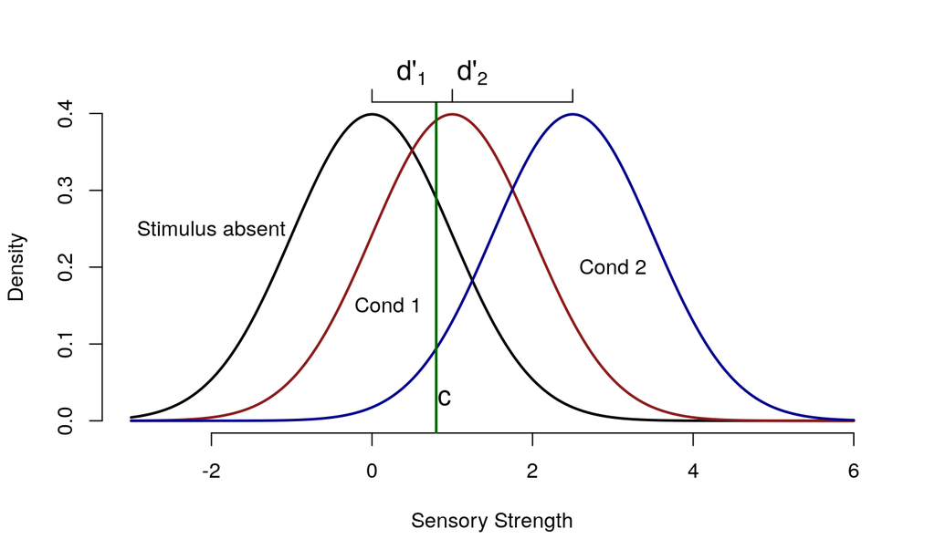

## SDT for 2 Conditions

```r
#par = c(d'1, d'2, c) y = c(hit1, miss1, fa1, cr1, hit2, miss2, fa2, cr2)
nll.sdt <- function(par3, y8){
  ll.sd(par3[c(1, 3)], y8[1:4]) +     #condition 1
    ll.sd(par3[2:3], y8[5:8])       #condition 2
}

### Data analysis
dat <- c(22, 28, 22, 28   #h, m, f, c for condition 1
         , 35, 15, 21, 29) #h, m, f, c for condition 2

par.m <- c(1, 2, 1) #starting values
out2  <- optim(par.m, nll.sdt, y8 = dat, hessian = T)
```

## Do we need two separate d'?

Estimate a model with only one d' for both conditions.

## Do we need two separate d'?

Estimate a model with only one d' for both conditions.

```r
#par = c(d', c) y = c(hit1, miss1, fa1, cr1, hit2, miss2, fa2, cr2)
nll.sdt.2 <- function(par2, y8){
  ll.sd(par2, y8[1:4]) +     #condition 1
    ll.sd(par2, y8[5:8])       #condition 2
}

### Data analysis
par.m <- c(1, .5) #starting values
out3  <- optim(par.m, nll.sdt.2, y8 = dat, hessian = T)
```

## Do we need two separate d'?

### Model Comparison

```r
#G2 between general and constrained model
(G2 <- 2 * (out3$value - out2$value))
```

```
## [1] 6.983578
```

```r
#p-value
1 - pchisq(G2, df = 1)
```

```
## [1] 0.008226097
```